# An introduction to spatial deformations using B-splines

Guilherme Ludwig, Ronaldo Dias, Paul Sampson

2020-02-07

This vignette describes how to install and use the `bsplinedef` package, a package for finding spatial deformations using the tensor product of B-splines. This is a work in progress and subject to change. For now, the package fits the semi-parametric covariance model
$$\Gamma(x_1, x_2) = \sigma^2(\|f_1(x_1,x_2) - f_2(x_1,x_2)\|; \boldsymbol\Delta)$$
where $x_1, x_2 \in G \subset \mathbb{R}^2$ are sampled spatial locations in a geostatistical domain $G;$ $f_1,$ $f_2$ are the tensor product of B-spline functions, each with $K_1 \times K_2$ basis functions, respectively; and $\sigma^2(\cdot)$ is a stationary, isotropic covariance function with parameters $\boldsymbol\Delta$. The parameters $\boldsymbol\Delta$ are estimated by minimizing
$$Q(\boldsymbol\Delta) \propto |\boldsymbol\Sigma|^{-n/2} \exp\left\{-\frac{1}{2}\left(\mathbf{Y} - \boldsymbol\mu \right)^t \boldsymbol\Sigma^{-1} \left(\mathbf{Y} - \boldsymbol\mu \right)\right\},$$
while the parameters $\boldsymbol\theta_1, \boldsymbol\theta_2$ are obtained by smoothing a multidimensional scaling transform of the original coordinates, regularized by a term that ensures no folding of the deformation surfaces $(f_1, f_2).$

## Installation

The most recent version of `bsplinedef` is available at https://github.com/guiludwig/bsplinedef. To install the package directly from github, we recommed the `install_github` function available from the `devtools` package.

```r
library(devtools) # install if missing
install_github("guiludwig/bsplinedef")
```

The `bsplinedef` package depends on `RandomFields`, `nloptr` and `splines`, among others. It also uses `knitr` and `rmarkdown` to build the documentation.

## Usage: simulated example

First, we will consider a simulated example.

```r
set.seed(1)
m <- 10
x1 <- (0:m)/m
x2 <- (0:m)/m
x <- as.matrix(expand.grid(x1,x2))
n <- nrow(x)
TIME <- 20
F1 <- function(x1,x2, a = 2.5, b = 1.0) {
x <- x1 - 0.5; y <- x2 - 0.5
angle <- a*exp(-(x*x+y*y)/(b*b)) + 3*pi/2
return(cos(angle)*x + sin(angle)*y + 0.5)
}
F2 <- function(x1,x2, a = 2.5, b = 1.0) {
x <- x1 - 0.5; y <- x2 - 0.5
angle <- a*exp(-(x*x+y*y)/(b*b)) + 3*pi/2
return(-sin(angle)*x + cos(angle)*y + 0.5)
}
```

The following figure displays the sampled spatial locations (in black) as well as the deformed locations with coordinates $y_1 = f_1(x_1,x_2)$ and $y_2 = f_2(x_1,x_2)$, in red. The black regular grid is also shown, deformed, in R. The marginal color maps display the functions $f_1$, $f_2.$

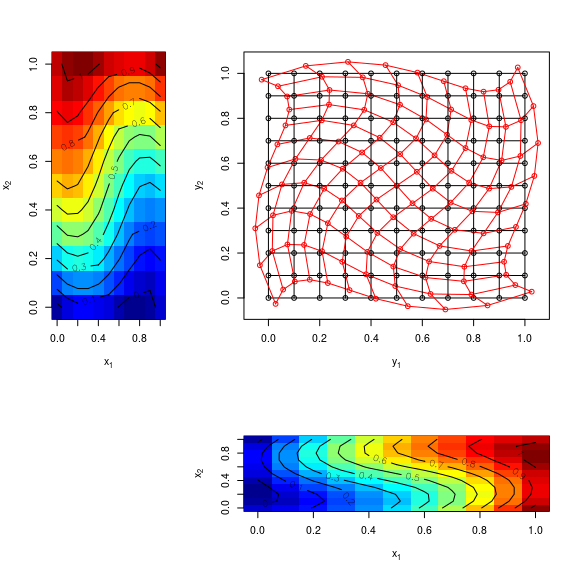

The `bsplinedef` inherits some syntax from the `RandomFields` package, particularly how to set up a covariance model for the D-distance. First, we will simulate data $Y$ on the D-coordinates $(y_1, y_2)$ using a stationary covariance model, with functions from the `RandomFields` package.

```r
 # Independent in time
covModel <- RMexp(var = 1, scale = .25, proj = "space") + RMnugget(var = 1) # Independent in time
data <- RFsimulate(covModel, x = F1(x[,1],x[,2]), y = F2(x[,1],x[,2]),
                   T = seq(from = 1, by = 1, len = TIME))
# Extracts values from object RFspatialPointsDataFrame
y  <- as.numeric(unlist(data@data))
```

```r
str(x)
```

```
##  num [1:121, 1:2] 0 0.1 0.2 0.3 0.4 0.5 0.6 0.7 0.8 0.9 ...
##  - attr(*, "dimnames")=List of 2
##   ..$ : NULL
##   ..$ : chr [1:2] "Var1" "Var2"
```

```r
str(y)
```

```
##  num [1:2420] -0.0229 -0.3691 -2.4061 0.1754 -0.9398 ...
```

The function `bdef` finds the appropriate deformations $\hat{f}_1,$ $\hat{f}_2,$ as well as estimating the parameters for the spatial covariance function. The default covariance function is a Matérn covariance function plus nugget effect, with differentiability parameter $\nu = 2.5$ (fixed), unknown variance $\sigma_\eta^2$, unknown scale parameter $\gamma$ and unknown nugget effect $\sigma_\varepsilon^2.$ In this case, we need to modify the default action to use an exponential covariance.

For example, fitting the model to the simulated dataset:

```r
# Parameters to be estimated set as NA
covModelM <- RMexp(var = NA, scale = NA) + RMnugget(var = NA)
model <- bdef(x, y, tim = 1:TIME, cov.model = covModelM,
              df1 = 6, df2 = 6)
```

Estimated parameters can be recovered with

```r
model$model # Covariance model
```

```
##
## User's variables:
##          exp.var     exp.s nugget.var
## value 0.88512032 0.1362162 0.80290386
## sd    0.07776658       Inf 0.02073394
##
##       #variab loglikelihood           AIC
##         3.000     -3895.917      7797.833
```

If, for some reason, one needs the spline coefficients, they can also be extracted with

```r
model$theta1 # Spline coefficients for f_1
```

```
##  [1] 0.0114247937 0.2268017836 0.3510730755 0.4938955121 0.7727632474
##  [6] 0.9785664002 0.0334719341 0.2365098222 0.3642934035 0.5620023681
## [11] 0.7441281770 0.9680291967 0.0347822481 0.1873339030 0.4268639574
## [16] 0.5752581422 0.7449294874 0.9514137947 0.0000000000 0.2061960564
## [21] 0.3579331066 0.5712543662 0.7735671839 0.9504205344 0.0005803341
## [26] 0.2224997030 0.3562370021 0.5937785661 0.7407514421 0.9921983136
## [31] 0.0259575566 0.2617640257 0.3797711307 0.6102485157 0.8177636301
## [36] 1.0223093798
```

The fitting process supports some customization. For example, one may be interested in a different covariance function. We may change it with the following command:

```r
# Value set to $nu = 2.5$
G <- RMmatern(nu = 2.5, var = NA, scale = NA) + RMnugget(var = NA)
# documentation, values left as NA are to be estimated
model.matern <- bdef(x, y, tim = 1:TIME, cov.model = G)
model.matern$model
```

```
##
## User's variables:
##       matern.var  matern.s nugget.var
## value 0.58741410 0.1401797 1.08752872
## sd    0.09237525       Inf 0.01444344
##
##       #variab loglikelihood           AIC
##         3.000     -3898.733      7803.465
```

## Plotting tools

We provide two plotting functions along with the `bsplinedef` package. The first one, named `plotGrid`, displays the deformation grid on the data.

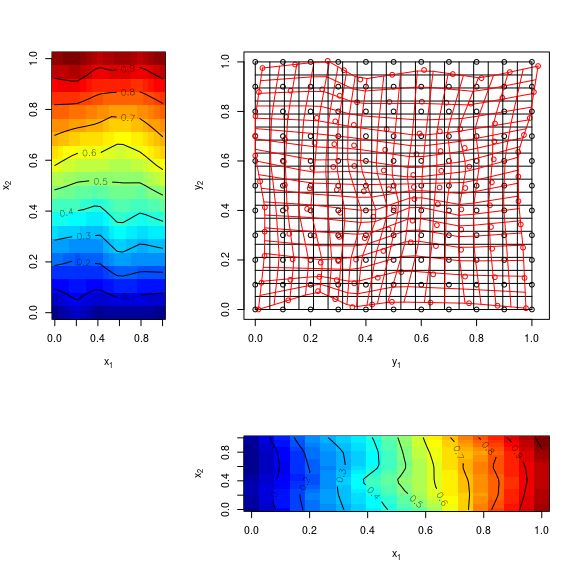

```r
plotGrid(model)
```

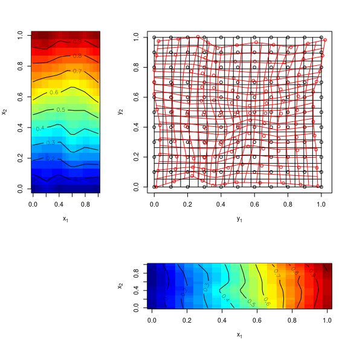

```r
plotGrid(model.matern)
```

The second function, `plotGDdist`, produces a comparison between sample covariances using the G-domain and D-domain distances for reference. It only works if all sampled sites have more than one observation, which might require pruning of the data to use.

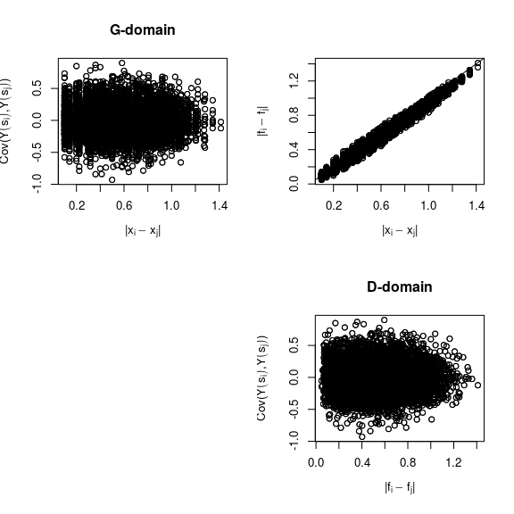

```r
plotGDdist(model)
```

One can also obtain the variogram using the `RandomFields` built in function.

```r
plot(model$model, ylim = c(0,2), xlim = c(0,0.7),
     model = list(`true model` = RMexp(var = 1, scale = .25) + RMnugget(var = 1)))
plot(model.matern$model, ylim = c(0,2), xlim = c(0,0.7),
     model = list(`true model` = RMexp(var = 1, scale = .25) + RMnugget(var = 1)))
```

[output not shown]